# Accessing and reusing public data from PANGAEA - Part 2

Johanna Jäger

2026-01-09

## 1. Setup of RStudio

```r
# List of packages
packages <- c("tidyverse", "dplyr", "ggplot2", "stringr", "sf", "forcats", "scales", "ggspatial", "lubridate")

# Installation if necessary and loading of packages
for (p in packages) {
  if (!require(p, character.only = TRUE)) {
    install.packages(p)
    library(p, character.only = TRUE)
  }
}
# set directory here, same as dataset_directory
knitr::opts_knit$set(root.dir = "C:/Users/jojom/Desktop/DataScience/oxygen/datasets/")
```

Check the version of used packages for reproducibility:

```r
installed.packages()[names(sessionInfo()$otherPkgs), "Version"]
```

```
## ggspatial    scales        sf lubridate   forcats   stringr     dplyr     purrr
##  "1.1.10"   "1.4.0"   "1.1-0"   "1.9.4"   "1.0.1"   "1.5.2"   "1.1.4"   "1.1.0"
##     readr     tidyr    tibble   ggplot2 tidyverse
##   "2.1.5"   "1.3.1"   "3.3.0"   "4.0.0"   "2.0.0"
```

```r
rm(p)
```

### 1.2 Setup of the basic variables

If not already done the [PANGAEA parameter list](https://www.pangaea.de/lists/parameter/all-byname) needs to be downloaded to `data_directory` (the parent directory) to store the parameter id, unit and name dynamically.

```r
parameter <- basename(dirname(getwd()))

# List the datasets
file_list <- list.files(
  pattern = paste0("PANGAEA_", parameter, "_\\d+_dataset_\\d+\\.txt$"),
  ignore.case = TRUE
)

# Extract the parameter id
id <- sub(".*_(\\d+)_dataset_.*", "\\1", file_list[1])

# Load parameter list to get correct unit and parameter name
param_table <- read.delim("../pangaea_parameters.tab",
                          sep = "\t", header = TRUE)
unit <- param_table$Unit[param_table$ID.parameter == id]
```

## 2. Combine datasets to one table

In order to merge all data records into one large table, I limited the input to the entries that each data record should contain:

- id
- date
- depth
- location (longitude/latitude)
- the chosen parameter (salinity, pH, temperature, oxygen, chlorophyll…)

### 2.1 Safe merging

```r
# Specifying the column names
clean_names <- c(
  "event", "date", "depth",
  "longitude", "latitude",
  parameter
)

# Desired data types
column_types <- list(
  event     = as.character,
  date      = as.character,
  depth     = as.numeric,
  longitude = as.numeric,
  latitude  = as.numeric
)

# Add parameter column type
column_types[[parameter]] <- as.numeric

# Track skipped datasets
skipped <- 0

# Read, clean, rename, type-convert each file
combined_data <- file_list %>%
  lapply(function(file) {

    read.delim(file) %>%
      mutate(
        id = str_extract(file, "(?<=dataset_)\\d+") %||% "unknown"
      ) %>%
      {
        df <- .

        # Rename messy columns
        for (clean in clean_names) {
          matched <- grep(clean, names(df),
                          ignore.case = TRUE, value = TRUE)

          if (length(matched) >= 1) {

            # If multiple parameter columns match...
            if (clean == parameter && length(matched) > 1) {

              # search for parameter
              cand <- matched[grepl(clean, matched, ignore.case = TRUE)]

              # prioritize unit
              cand_unit <- cand[grepl(unit, cand, ignore.case = TRUE)]

              # exactly one column --> keep
              if (length(cand_unit) == 1) {
                best <- cand_unit

              # no unit column --> shortest
              } else if (length(cand_unit) == 0) {
                best <- cand[which.min(nchar(cand))]

              # more than one --> shortest
              } else {
                best <- cand_unit[which.min(nchar(cand_unit))]
              }

            } else {
              # Match all other columns with shortest match
              best <- matched[which.min(nchar(matched))]
            }

            # Apply renaming
            names(df)[names(df) == best] <- clean
          }
        }

        # Keep only relevant columns
        keep_cols <- c("id", clean_names)
        df <- df %>% select(any_of(keep_cols))

        # Convert types
        for (col in names(column_types)) {
          if (col %in% names(df)) {
            df[[col]] <- column_types[[col]](df[[col]])
          }
        }

        df
      }
  }) %>%
  bind_rows()

# Make ID numeric
combined_data$id <- as.numeric(combined_data$id)

# Save final object with parameter name
assign(paste0("combined_", parameter), combined_data)

# Print skipped dataset count
message(skipped, " datasets were skipped due to ambiguous or missing unit matches.")
```

```
## 0 datasets were skipped due to ambiguous or missing unit matches.
```

```r
# Clean up
rm(combined_data)
gc()
```

```
##            used  (Mb) gc trigger  (Mb) max used  (Mb)
## Ncells  2360022 126.1    3584631 191.5  3220649 172.1
## Vcells 24363052 185.9   45561525 347.7 43436574 331.4
```

### 2.2 Adding relevant metadata

The way in which the parameter was measured is another important aspect that should be taken into account, especially with regard to possible troubleshooting. This information is stored in the metadata. Therefore, we filter the corresponding metadata table by device and add the column to the combined table.

```r
metadata_file <- list.files(
  path = "..",
  pattern = paste0(".*", parameter, ".*", id, ".*metadata.*\\.txt$"),
  ignore.case = TRUE,
  full.names = TRUE
)[1]

metadata <- read.delim(metadata_file) %>%
  select(ID, device) %>%
  rename(id = ID)

# Add (join) the devices to the big table
assign(
  paste0("combined_", parameter),
  get(paste0("combined_", parameter)) %>% left_join(metadata, by = "id")
)
```

## 3 Prepare the data for visualization

When preparing the data for visualisation, spatial and statistical filtering must be performed. This involves sorting out a large amount of data; the exact amount is listed in this step.

### 3.1 Spatial filtering

Since the bounding box in pangaeapy is based on the coordinates specified in the metadata, the downloaded data sets may contain data points that lie outside of it. Therefore, an additional geographical filter step must be inserted here. First, the bounding box is set again and all data points outside it are removed. Then a polygon of the Baltic Sea is used to filter out the remaining points that lie within the bounding box but outside the Baltic Sea (e.g. northwest of Norway).

**Note**: You need to download the Polygon for the Worlds Seas [here](https://marineregions.org/downloads.php#iho) and unzip the files. The `baltic_names` filter is hard-coded, so for different spatial settings please take that into consideration.

### 3.2 Statistical filtering

It is necessary to filter out impossible values in order to obtain representative data. Errors can occur when measuring with devices or entering data into tables. However, because this workflow is intended to function for all possible different parameters, it is not practical to set hard-coded limits. A robust method for environmental data is the median absolute deviation [(MAD)](https://en.wikipedia.org/wiki/Median_absolute_deviation), which is not greatly affected by outliers.

The filter removes items whose values are: $| x - median(x) | > k * MAD(x)$.  
$k$ is the threshold and usually between 5 (conservative) and 3 (strict).

```r
baltic_simple <- {
  # Load the world seas polygon
  world_seas <- st_read("../World_Seas_IHO_v3/World_Seas_IHO_v3/World_Seas_IHO_v3.shp")

  # Filter for relevant regions
  baltic_names <- c(
    "Baltic Sea",
    "Gulf of Bothnia",
    "Gulf of Finland",
    "Gulf of Riga",
    "Kattegat"
  )

  world_seas %>%
    filter(NAME %in% baltic_names) %>%
    st_make_valid() %>%
    st_union() %>% # merge the sub-polygons to one
    st_sf(geometry = ., crs = st_crs(world_seas)) %>%
    st_simplify(dTolerance = 1500) # simplifying polygon complexity
}
bbox <- st_bbox(baltic_simple)

df <- get(paste0("combined_", parameter))
n_start <- nrow(df) # initial row number

# Remove NA coordinates
df <- df %>% filter(!is.na(longitude), !is.na(latitude))
n_after_na <- nrow(df)

# Bounding box filter
df <- df %>%
  filter(
    longitude >= bbox["xmin"], longitude <= bbox["xmax"],
    latitude >= bbox["ymin"], latitude <= bbox["ymax"]
  )
n_after_bbox <- nrow(df)

# Spatial intersection
df <- {
  df_sf <- st_as_sf(df, coords = c("longitude", "latitude"), crs = 4326, remove = FALSE) # converting to an sf point object
  baltic_simple2 <- st_transform(baltic_simple, st_crs(df_sf))
  inside <- st_intersects(df_sf, baltic_simple2, sparse = FALSE)[,1] # checking if data point lies within polygon
  df_sf[inside, ] %>% st_drop_geometry() # return to normal dataframe
}
n_after_spatial <- nrow(df)

# MAD filtering (remove parameter NAs and statistical outliers)
df_final <- {
  x <- df[[parameter]]
  med <- median(x, na.rm = TRUE)
  mad_val <- mad(x, na.rm = TRUE)

  df %>%
    filter(is.finite(.data[[parameter]])) %>%
    filter(abs(.data[[parameter]] - med) <= 5 * mad_val) # Threshold of 5 (conservative)
}
n_after_mad <- nrow(df_final)
assign(paste0("filtered_", parameter), df_final)

# Compute losses
lost_na      <- n_start        - n_after_na
lost_bbox    <- n_after_na     - n_after_bbox
lost_spatial <- n_after_bbox   - n_after_spatial
lost_mad     <- n_after_spatial - n_after_mad

# Print summary
cat("\n--- Data loss summary ---\n")
```

```
##
## --- Data loss summary ---
```

```r
cat(sprintf("Original rows:                %d\n", n_start))
```

```
## Original rows:                2368551
```

```r
cat(sprintf("Lost due to NA coordinates:   %d (%.2f%%)\n", lost_na,      100 * lost_na      / n_start))
```

```
## Lost due to NA coordinates:   574 (0.02%)
```

```r
cat(sprintf("Lost by bounding box:         %d (%.2f%%)\n", lost_bbox,    100 * lost_bbox    / n_start))
```

```
## Lost by bounding box:         1156906 (48.84%)
```

```r
cat(sprintf("Lost by spatial filtering:    %d (%.2f%%)\n", lost_spatial, 100 * lost_spatial / n_start))
```

```
## Lost by spatial filtering:    726297 (30.66%)
```

```r
cat(sprintf("Lost by MAD filtering:        %d (%.2f%%)\n", lost_mad,     100 * lost_mad     / n_start))
```

```
## Lost by MAD filtering:        51309 (2.17%)
```

```r
cat(sprintf("Final rows:                   %d (%.2f%% retained)\n",
            n_after_mad, 100 * n_after_mad / n_start))
```

```
## Final rows:                   433465 (18.30% retained)
```

```r
cat("----------------------------\n")
# Delete the temporary variable to maintain an overview of the environment
rm(df, n_start, n_after_na, n_after_bbox, n_after_spatial, n_after_mad,
   lost_na, lost_bbox, lost_spatial, lost_mad,
   df_sf, baltic_simple2, inside, x, med, mad_val, baltic_names)
gc()
```

```
##            used  (Mb) gc trigger   (Mb)  max used   (Mb)
## Ncells  6723476 359.1   18973034 1013.3  18973034 1013.3
## Vcells 55687915 424.9  101580591  775.0 101259871  772.6
```

Perform a *sanity check* to ensure the statistical filtering removed outliers (like negative oxygen concentrations) by inspecting the numerical range.

```r
# before MAD filtering
range(get(paste0("combined_", parameter))[[parameter]], na.rm = TRUE)
```

```
## [1] -4416.885  2654.233
```

```r
# after MAD filtering
range(get(paste0("filtered_", parameter))[[parameter]], na.rm = TRUE)
```

```
## [1] -91.1100 730.3029
```

## 4 Data visualization

The following graphs are designed to facilitate an initial comprehension of the data. This overview can then be used to inform decisions regarding further visualization or processing of the data.

### 4.1 Overview parameter

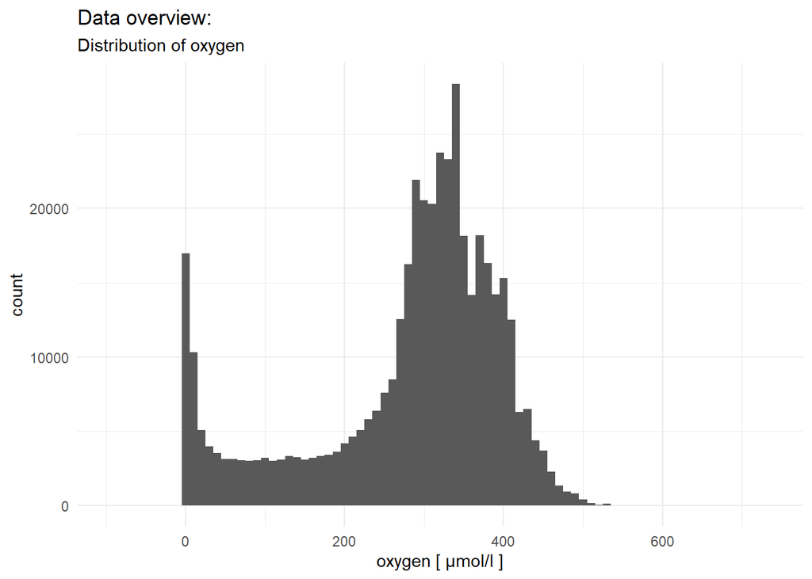

```r
# An overview of parameter distribution
ggplot(get(paste0("filtered_", parameter)),
       aes(x = .data[[parameter]])) +
  geom_histogram(binwidth = 10) +
  labs(
    title = "Data overview:",
    subtitle = paste("Distribution of", parameter),
    x = paste(parameter, "[", unit, "]"),
    y = "count"
  ) +
  theme_minimal()
```

### 4.2 Overview devices

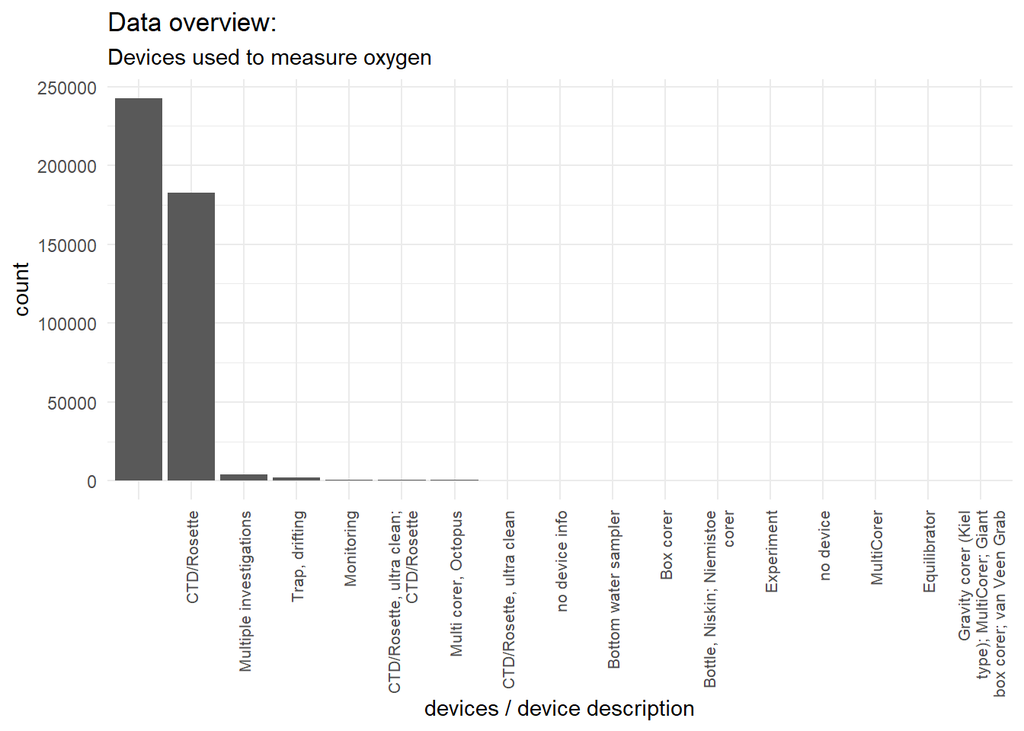

```r
# An overview of used devices for measuring
ggplot(get(paste0("filtered_", parameter)),
           aes(x = fct_infreq(device))) +
  geom_bar() +
  scale_x_discrete(labels = function(x) str_wrap(x, width = 25)) +
  labs(
    title = "Data overview:",
    subtitle = paste("Devices used to measure", parameter),
    x = "devices / device description",
    y = "count"
  ) +
  theme_minimal() +
  theme(axis.text.x = element_text(angle = 90, vjust = 0.5, hjust = 1, size = 8))
```

It is notable that in many (or most) metadata entries, no devices are documented. Furthermore, there does not appear to be any preselection, as there are different names for the same device.

### 4.3 Overview temporal data distribution

```r
df_name <- paste0("filtered_", parameter)
df <- get(df_name)

df$date <- parse_date_time(
  df$date,
  orders = c("ymd HMS", "ymd")
)
```

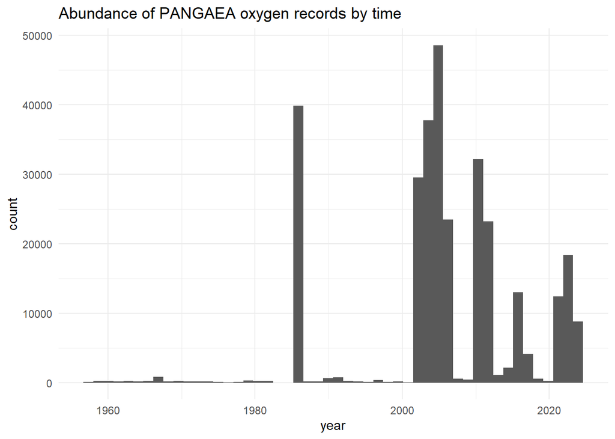

```r
ggplot(df, aes(x = date)) +
  geom_histogram(bins = 50) +
  labs(
    title = paste("Abundance of PANGAEA", parameter, "records by time"),
    x = "year",
    y = "count"
  ) +
  theme_minimal()
```

For obvious reasons, the years from 2000 onwards are represented much more frequently, although some older research has also been included.

### 4.4 Spatial visualization

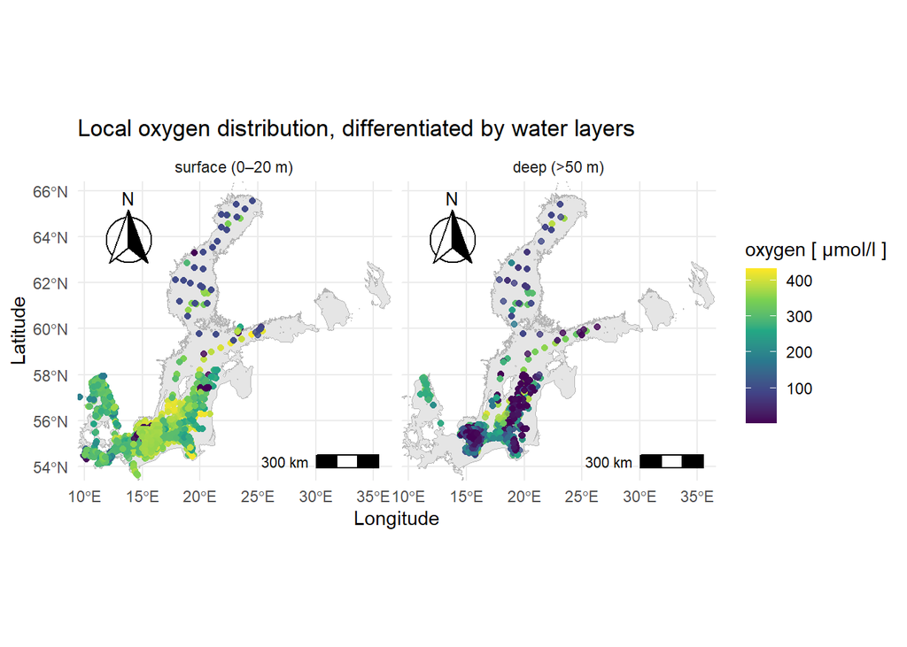

```r
df_surface <- get(paste0("filtered_", parameter)) %>%
  filter(depth <= 20) %>% # filter for surface waters (< 20m depth)
  select(longitude, latitude, all_of(parameter)) %>%
  mutate(layer = "surface (0–20 m)")

df_deep <- get(paste0("filtered_", parameter)) %>%
  filter(depth > 50) %>% # filter for deeper waters (> 50m depth)
  select(longitude, latitude, all_of(parameter)) %>%
  mutate(layer = "deep (>50 m)")

df_plot <- bind_rows(df_surface, df_deep) %>% # combine both layers
  mutate(layer = factor(layer, levels = c("surface (0–20 m)", "deep (>50 m)")))

# dynamical limits containing 90% of the data
lims <- quantile(df_plot[[parameter]], probs = c(0.05, 0.95), na.rm = TRUE)

ggplot() +
  geom_sf(data = baltic_simple, fill = "grey90", color = "grey70") + #background map
  geom_point(
    data = df_plot,
    aes(x = longitude, y = latitude, color = .data[[parameter]]),
    size = 1.5, alpha = 0.8
  ) +
  facet_wrap(~ layer, ncol = 2) + # two images side by side
  scale_color_viridis_c(
    limits = lims,
    oob = scales::squish   # prevents grey points
  ) +
  coord_sf(xlim = c(bbox["xmin"], bbox["xmax"]),
           ylim = c(bbox["ymin"], bbox["ymax"]),
           expand = FALSE) +
  theme_minimal() +
  labs(
    title = paste("Local", parameter, "distribution, differentiated by water layers"),
    x = "Longitude",
    y = "Latitude",
    color = paste(parameter, "[", unit, "]")
  ) +
  annotation_scale(location = "br") +
  annotation_north_arrow(
    location = "tl",
    style = north_arrow_fancy_orienteering)
```

```r
rm(df_surface, df_deep, lims, df_plot)
```

## 5. Results and Discussion

PANGAEA presents itself as a FAIR-aligned repository, but several practical issues limit how findable, interoperable, and reusable the data truly are. Date fields are inconsistent, appearing either as pure dates or as date–time combinations, which complicates automated parsing and merging. Many datasets contain multiple columns for the same parameter, often with different units or naming conventions, making automated selection unreliable. The raw dataframes are large and cluttered, and although they become manageable after trimming, the initial heterogeneity slows down processing. Some datasets contain physically impossible values even after statistical filtering, indicating gaps in quality control.

Across all steps, it is difficult to avoid hard‑coding because naming conventions, units, and metadata structures vary widely between datasets. These issues collectively undermine the FAIR principles, especially interoperability and reusability, by shifting the burden of harmonization from the repository to the user. The metadata is curated by PANGAEA, but the datasets themselves are not, meaning that scientists cause inconsistencies that affect the overall data quality.